# O365 SSAT EDA

```r
#if(!require(bayesian_first_aid)){devtools::install_github("rasmusab/bayesian_first_aid")}
if(!require(easypackages)){install.packages("easypackages")}
library(easypackages)
packages("plyr","dplyr","ggplot2", "readr", "tidyr", "gridExtra", "readxl", "stringr", "lubridate",
         "xda", "magrittr","funModeling",   prompt = TRUE)
```

# Abstract

Business question: Why is SSAT dropping Nov 2017 - Jan 2018?

# Introduction

January 26, 2018, Valorem was asked to evaluate SSAT data to understand if there were trends in the data to explain why SSAT scores have fallen.

| MonthYear | NSATAveraged |
| --- | --- |
| 7/1/2017 0:00 | 154.5181 |
| 8/1/2017 0:00 | 154.4314 |
| 9/1/2017 0:00 | 154.6326 |
| 10/1/2017 0:00 | 154.6831 |
| 11/1/2017 0:00 | 152.6882 |
| 12/1/2017 0:00 | 151.4207 |
| 1/1/2018 0:00 | 150.4597 |

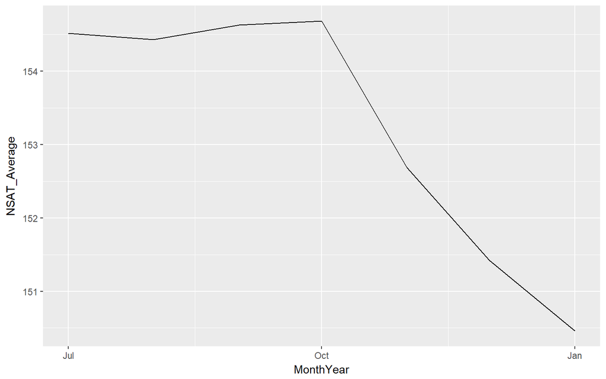

Microsoft identified the following business issues that may have impacted the SSAT Scores:

```
1. Data corruption - is it an issue?
2. Rave 2.0 - deployed around the same time as the SSAT drop
3. DAO and PWRv2 - routing technologies also launched around the same time
    a. How to route to partners and agents
    b. MS now decides who gets what ticket
4. Migration - which buckets a customer/tenant falls into - bigger stacks than CI/NCI
    a. Customers that are inside or outside Concierge entirely (Partner queue is one of the stacks)
        i. Think support areas, customers, < 150 seats, >150 classic (Modern), Partners, Premier
        ii. Who moved when - was that an impact
```

# Data

1. Survey data (survey provided by the customer – `SSATSurveyData_Jan25_2018.xlsx`)
2. Ticket data (meta data about the ticket which was the subject of the SSAT Survey).
3. Customer data (metadata about the customer who filed the ticket).

## Survey Data Review

```r
SurveyData <- read_excel("~/Github/Valorem/ClientProjects/MS_O365/data/SSATSurveyData_Jan25_2018.xlsx")
```

The survey data has 12147 records and 87 variables.

### Raw View 1

```r
glimpse(SurveyData)
```

```
## Observations: 12,147
## Variables: 87
## $ FeedbackIdInSource              <chr> "1d218cb7-bb60-48eb-af91-0be83...
## $ FeedbackDateTime                <chr> "2017-12-04 16:00:18.0060502 +...
## $ DetectedFeedbackLanguage        <chr> NA, NA, NA, NA, NA, NA, NA, NA...
## $ Feature                         <chr> "ModernTroubleshooting", "Mode...
## $ AdditionalInfo                  <chr> "user:submit; Experments:Modal...
## $ Page                            <chr> "Modal:Default", "Modal:Defaul...
## $ Partner                         <chr> "Office365", "Office365", "Off...
## $ Rating                          <dbl> 5, 5, 5, 5, 3, 5, 5, 5, 5, 4, ...
## $ Sku                             <chr> "SMBSku", "SMBSku", "SMBSku", ...
## $ TenantId                        <chr> "2aef675f-ac5d-4340-9a48-dd94b...
## $ SnapshotTime                    <chr> "2017-12-04 17:27:23.8658962 +...
## $ UserId                          <chr> "10037FFE90C1370D", "10037FFE8...
## $ Text_Scrubbed                   <chr> NA, NA, NA, NA, NA, NA, NA, NA...
```

[output cut: 74 more lines]

### Raw View 2

```r
df_status(SurveyData)
```

```
##                           variable q_zeros p_zeros  q_na  p_na q_inf p_inf
## 1               FeedbackIdInSource       0    0.00     0  0.00     0     0
## 2                 FeedbackDateTime       0    0.00     0  0.00     0     0
## 3         DetectedFeedbackLanguage       0    0.00 10454 86.06     0     0
## 4                          Feature       0    0.00     0  0.00     0     0
## 5                   AdditionalInfo       0    0.00     0  0.00     0     0
## 6                             Page       0    0.00     0  0.00     0     0
## 7                          Partner       0    0.00     0  0.00     0     0
## 8                           Rating       1    0.01     0  0.00     0     0
## 9                              Sku       0    0.00     0  0.00     0     0
## 10                        TenantId       0    0.00     0  0.00     0     0
## 11                    SnapshotTime       0    0.00     0  0.00     0     0
## 12                          UserId       0    0.00     0  0.00     0     0
## 13                   Text_Scrubbed       0    0.00 10453 86.05     0     0
## 14                  Email_Scrubbed       0    0.00  9222 75.92     0     0
```

[output cut: 161 more lines]

## Categorical Variables

```r
myChar <- charSummary(SurveyData)
myChar <-  tibble::rownames_to_column(myChar, var = "Variable")
arrange(myChar, desc(myChar[,3])) %>% head(5)
```

```
##                   Variable     n  miss    miss% unique
## 1 DetectedFeedbackLanguage  1693 10454 86.06240     26
## 2            Text_Scrubbed  1694 10453 86.05417   1656
## 3                 Verbatim  1694 10453 86.05417   1656
## 4           Email_Scrubbed  2925  9222 75.91998      7
## 5            DefaultDomain 11970   177  1.45715  10874
##                                                                                                top5levels:count
## 1                                                                          en:1316, es:115, pt:63, de:62, fr:34
## 2                                                         Excellent:7, good:5, Good:4, Very good:4, excellent:3
## 3                                                         Excellent:7, good:5, Good:4, Very good:4, excellent:3
## 4                                                         <PII>:2920, <PII>es:1, <PII>ion:1, <PII>r:1, <PII>t:1
## 5 NULL:60, drlglobal.onmicrosoft.com:13, lrfonline.onmicrosoft.com:13, bushwickmetals.com:11, pragermetis.com:8
```

There are 4 variables where so much data is missing it is unlikely to be useful in any type of analysis. Remove them.

Because it might be interesting, save the `Verbatim` data. Perhaps perform sentiment analysis. **ToDo**

```r
verbatim <- SurveyData %>% select(Verbatim) %>% filter(!is.na(Verbatim))
SurveyData <- select(SurveyData, -c(DetectedFeedbackLanguage, Text_Scrubbed, Verbatim, Email_Scrubbed))
```

Remove any variables where there is no variance, ie, where the number of unique values in a given column = 1.

```r
arrange(myChar, myChar[,5]) %>% head(10)
```

```
##               Variable     n miss     miss% unique
## 1              Feature 12147    0 0.0000000      1
## 2              Partner 12147    0 0.0000000      1
## 3        isPIIScrubbed 12147    0 0.0000000      1
## 4    CALastUpdatedTime 12147    0 0.0000000      1
## 5             Activity 12147    0 0.0000000      1
## 6  ExtensionAttributes 12147    0 0.0000000      1
## 7    ReleaseTrackState 12098   49 0.4033918      4
## 8                 Page 12147    0 0.0000000      5
## 9                  Sku 12147    0 0.0000000      5
## 10         TenantState 12020  127 1.0455256      5
##                                                                                                                 top5levels:count
## 1                                                                                                    ModernTroubleshooting:12147
## 2                                                                                                                Office365:12147
## 3                                                                                                                     NULL:12147
## 4                                                                                                                     NULL:12147
## 5                                                                                                            AdminFeedback:12147
## 6                                                                                                                     NULL:12147
## 7                                                                    StandardRelease:8679, StagedRollout:1952, FirstRelease:1467
## 8  Modal:Default:12127, Modal:Feedback:16, Modal:Comentarios:2, Modal:Отзыв:1, Modal:Opinia:1
## 9                                                                       ESku:5621, SMBSku:5506, EduSku:999, PSkuOnSMB:17, PSku:4
## 10                                                                                   Active:11955, NULL:60, Unknown:4, Deleted:1
```

```r
SurveyData <- select(SurveyData, -c(Feature, Partner, isPIIScrubbed, CALastUpdatedTime, Activity, ExtensionAttributes))
```

Change the variable type from `character` to `factor` for several columns.

```r
#Use a pipe (%<>%) from the magrittr package to convert character column to a factor
SurveyData$Page %<>% factor
SurveyData$Sku %<>% factor
SurveyData$SignupCountry %<>% factor
SurveyData$SignupCountryCode %<>% factor#delete this or one above - do not need 2
SurveyData$TenantState %<>% factor
SurveyData$Type %<>% factor
SurveyData$ReleaseTrackState %<>% factor
SurveyData$ChannelType %<>% factor
```

## Character to Data Variables

```r
SurveyData$FeedbackDateTime <- ymd(str_sub(SurveyData$FeedbackDateTime, 1,10))
SurveyData$SnapshotTime <- ymd(str_sub(SurveyData$SnapshotTime, 1,10))
SurveyData$EventDatetime <- ymd(str_sub(SurveyData$EventDatetime, 1,10))
SurveyData$CreatedDate <- ymd(str_sub(SurveyData$CreatedDate, 1,10))
SurveyData$CreateDateOfFirstSubscription <- ymd(str_sub(SurveyData$CreateDateOfFirstSubscription, 1,10))
SurveyData$LastUpdatedTime <- ymd(str_sub(SurveyData$LastUpdatedTime, 1,10))
SurveyData$CALastUpdatedTime__1 <- ymd(str_sub(SurveyData$CALastUpdatedTime__1, 1,10))
```

## Numerical Data

```r
SurveyData %>% select_if(is.numeric) %>% glimpse()
```

```
## Observations: 12,147
## Variables: 47
## $ Rating                          <dbl> 5, 5, 5, 5, 3, 5, 5, 5, 5, 4, ...
## $ Rating__1                       <dbl> 5, 5, 5, 5, 3, 5, 5, 5, 5, 4, ...
## $ TotalSubscriptionsCount         <dbl> 4, 2, 2, 3, 3, 4, 1, 2, 2, 5, ...
## $ PaidSubscriptionsCount          <dbl> 4, 2, 2, 3, 3, 4, 1, 2, 2, 3, ...
## $ TrialSubscriptionsCount         <dbl> 0, 0, 0, 0, 0, 0, 0, 0, 0, 2, ...
## $ TotalUsers                      <dbl> 63, 61, 318, 7, 116, 274, 19, ...
## $ LicensedUsers                   <dbl> 50, 53, 99, 6, 101, 181, 19, 7...
## $ AllUpSeats                      <dbl> 10083, 54, 117, 5, 101, 200018...
## $ AllUpSeatsPaid                  <dbl> 10083, 54, 117, 5, 101, 200018...
## $ AllUpSeatsTrial                 <dbl> 0, 0, 0, 0, 0, 0, 0, 0, 0, 0, ...
## $ EopSeats                        <dbl> 0, 0, 0, 0, 0, 0, 0, 0, 0, 0, ...
## $ ExchangeSeats                   <dbl> 48, 54, 117, 5, 93, 182, 17, 7...
## $ InformationWorkerSeats          <dbl> 10000, 0, 0, 0, 0, 2000000, 0,...
```

[output cut: 34 more lines]

All the values can be changed to an `int`.

```r
SurveyData <- SurveyData %>% mutate_if(is.numeric, as.integer)
```

Look deeper into the numerical data.

```r
myNum <- numSummary(SurveyData)
myNum <-  tibble::rownames_to_column(myNum, var = "Variable")
myNum
```

```
##                           Variable     n      mean       sd      max min
## 1                           Rating 12147  4.22e+00 1.23e+00        5   0
## 2                        Rating__1 12147  4.22e+00 1.23e+00        5   0
## 3          TotalSubscriptionsCount 12147  4.83e+00 5.26e+00      156   0
## 4           PaidSubscriptionsCount 12147  4.65e+00 5.21e+00      156   0
## 5          TrialSubscriptionsCount 12147  1.84e-01 5.80e-01       24   0
## 6                       TotalUsers 12087  3.46e+03 2.84e+04  1644729   0
## 7                    LicensedUsers 12147  2.18e+03 2.06e+04  1122060   0
## 8                       AllUpSeats 12147  3.59e+05 7.30e+05 17000000   2
## 9                   AllUpSeatsPaid 12147  3.42e+05 6.90e+05 17000000   0
## 10                 AllUpSeatsTrial 12147  9.86e+03 1.14e+05  4000000   0
## 11                        EopSeats 12147  0.00e+00 0.00e+00        0   0
## 12                   ExchangeSeats 12147  6.73e+04 3.42e+05  8000000   0
## 13          InformationWorkerSeats 12147  3.09e+05 6.16e+05  4550000   0
## 14                       LyncSeats 12147  6.36e+04 3.14e+05  3500000   0
```

[output cut: 177 more lines]

Sorting the data may reveal some insight.

```r
arrange(myNum, myNum[,7])
```

```
##                           Variable     n      mean       sd      max min
## 1                         EopSeats 12147  0.00e+00 0.00e+00        0   0
## 2         IsDedicatedOnMultiTenant 12087  0.00e+00 0.00e+00        0   0
## 3                         IsActive 12147  9.77e-01 1.49e-01        1   0
## 4                        IsCharity 12147  7.72e-02 2.67e-01        1   0
## 5                      IsConcierge 12147  6.25e-01 4.84e-01        1   0
## 6                      IsEducation 12147  8.11e-02 2.73e-01        1   0
## 7                   IsExpressRoute 12147  2.31e-03 4.80e-02        1   0
## 8                     IsGovernment 12147  6.59e-03 8.09e-02        1   0
## 9                  IsPartnerTenant 12147  2.14e-03 4.62e-02        1   0
## 10                       IsPremier 12147  4.83e-02 2.14e-01        1   0
## 11   IsRestrictRmsIndividualSignUp 12087  8.11e-03 8.97e-02        1   0
## 12                          IsTest 12147  4.94e-04 2.22e-02        1   0
## 13                  DirSyncEnabled 12087  4.25e-01 4.94e-01        1   0
## 14                    HasEducation 12147  8.21e-02 2.74e-01        1   0
```

[output cut: 177 more lines]

Note `EopSeats` havs only one value, 0, and therefore does not provide any data insight. Remove it.

```r
SurveyData <- SurveyData %>% select(-c(EopSeats))
```

## Logical Data

There are a number of variables (23) that appear to be logical variables. Be careful, there are variables that appear logical but have values outside of `0 - 1`: `ExperienceIndex` and `NumberOfTicketsToDate`.

```r
filter(myNum, nunique == 2, min >= 0)
```

```
##                    Variable     n     mean     sd max min range nunique
## 1                  IsActive 12147 0.977361 0.1488   1   0     1       2
## 2                 IsCharity 12147 0.077221 0.2670   1   0     1       2
## 3               IsConcierge 12147 0.624681 0.4842   1   0     1       2
## 4  IsDedicatedOnMultiTenant 12087 0.000000 0.0000   0   0     0       2
## 5               IsEducation 12147 0.081090 0.2730   1   0     1       2
## 6            IsExpressRoute 12147 0.002305 0.0480   1   0     1       2
## 7              IsGovernment 12147 0.006586 0.0809   1   0     1       2
## 8           IsPartnerTenant 12147 0.002140 0.0462   1   0     1       2
## 9                 IsPremier 12147 0.048325 0.2145   1   0     1       2
## 10                   IsTest 12147 0.000494 0.0222   1   0     1       2
## 11             HasEducation 12147 0.082078 0.2745   1   0     1       2
## 12              HasExchange 12147 0.936281 0.2443   1   0     1       2
## 13                  HasLync 12147 0.884992 0.3190   1   0     1       2
## 14                  HasPaid 12147 0.954557 0.2083   1   0     1       2
```

[output cut: 57 more lines]

```r
#to change all the appropraite Ints to Logical, removed from df, modify and then cbind
SurveyData1 <- SurveyData
myLogicalNames <- filter(myNum, nunique == 2, min >= 0)[1]
SurveyData1 <- select(SurveyData1, -one_of(myLogicalNames[,1]))
SurveyData2 <- SurveyData %>% select(myLogicalNames[,1]) %>% mutate_all(as.logical)
SurveyData <- cbind(SurveyData1, SurveyData2)
rm(SurveyData1, SurveyData2)
glimpse(SurveyData)
```

```
## Observations: 12,147
## Variables: 76
## $ FeedbackIdInSource              <chr> "1d218cb7-bb60-48eb-af91-0be83...
## $ FeedbackDateTime                <date> 2017-12-04, 2017-12-15, 2018-...
## $ AdditionalInfo                  <chr> "user:submit; Experments:Modal...
## $ Page                            <fctr> Modal:Default, Modal:Default,...
## $ Rating                          <int> 5, 5, 5, 5, 3, 5, 5, 5, 5, 4, ...
## $ Sku                             <fctr> SMBSku, SMBSku, SMBSku, SMBSk...
## $ TenantId                        <chr> "2aef675f-ac5d-4340-9a48-dd94b...
## $ SnapshotTime                    <date> 2017-12-04, 2017-12-15, 2018-...
## $ UserId                          <chr> "10037FFE90C1370D", "10037FFE8...
## $ omstenantid                     <chr> "2AEF675F-AC5D-4340-9A48-DD94B...
## $ Rating__1                       <int> 5, 5, 5, 5, 3, 5, 5, 5, 5, 4, ...
## $ EventDatetime                   <date> 2017-12-04, 2017-12-15, 2018-...
## $ EventIdentifierInSource         <chr> "1d218cb7-bb60-48eb-af91-0be83...
```

[output cut: 63 more lines]

## Replace NAs

```r
#https://sebastiansauer.github.io/sum-isna/
myNA <- SurveyData %>% summarise_all(funs(sum(is.na(.))))
myNA <- gather(myNA, key="Variable", value = "NA_Count", FeedbackIdInSource:CALastUpdatedTime__1, factor_key = FALSE)
arrange(myNA, desc(NA_Count)) %>% filter(NA_Count >0)
```

```
##    IsActive IsCharity IsConcierge IsDedicatedOnMultiTenant IsEducation
## 1         0         0           0                       60           0
## 2         0         0           0                       60           0
## 3         0         0           0                       60           0
## 4         0         0           0                       60           0
## 5         0         0           0                       60           0
## 6         0         0           0                       60           0
## 7         0         0           0                       60           0
## 8         0         0           0                       60           0
## 9         0         0           0                       60           0
## 10        0         0           0                       60           0
## 11        0         0           0                       60           0
##    IsExpressRoute IsGovernment IsPartnerTenant IsPremier IsTest
## 1               0            0               0         0      0
## 2               0            0               0         0      0
```

[output cut: 45 more lines]

From: Dean Avila Sent: Monday, January 29, 2018 12:22 PM To: Erfan Najmi ernajmi@microsoft.com; Nikhil Verma nikhilv@microsoft.com; Cliff Weaver cweaver@valorem.com; Ankit Choudhari ankit.choudhari@microsoft.com; Yun Wang Yun.Wang@microsoft.com; Cheng Wu wucheng@microsoft.com Subject: RE: SSAT Drop - New Priority

Per discussion with Cheng and Yun, let’s reduce this list to tenant data:

[SignupCountry] (can be used as regions) [TotalUsers] (currently we use this for seat count) [NumberOfTicketsToDate] [DirSyncEnabled] [LastTicketTime] (days to last ticket, theme of last ticket, status of the last ticket and other derived features can also be used) [IsActive][IsCharity] [IsConcierge][IsDedicatedOnMultiTenant] [IsEducation][IsExpressRoute] [IsGovernment][IsPartnerTenant] [IsPremier]